# syndata_jetengine_singletable

#### Synthetic Data

##### Purpose: This notebook is a proof-of-concept to get familiar with generating synthetic data. I used the references below to get acquainted with the process and to try it on a different dataset.

I used the Synthetic Data Vault (SDV), which is a Python library designed to be a one-stop shop for creating tabular synthetic data. The SDV offers multiple machine learning models -- ranging from classical statistical methods (Copulas) to deep learning methods (GANs). It can generate data for single tables, multiple connected tables or sequential tables.  
In this notebook, I used a Copulas synthesizer.

##### Why do we need Synthetic data?

- Privacy and Compliance: Real-world datasets often contain sensitive information. Synthetic data, however, does not carry the same privacy concerns since it's generated and doesn't correspond to real individuals.
- Data Imbalance: Synthetic data can help alleviate problems with imbalanced datasets, where one class of data is over-represented compared to another. This is a common issue in machine learning and can lead to biased or incorrect models. Synthetic data can be generated to balance the dataset, improving the performance of the machine learning model.
- Data Augmentation: Synthetic data can augment existing datasets, particularly when real-world data is scarce or expensive to obtain. For instance, in fields like autonomous driving or healthcare, acquiring enough real-world data can be challenging and costly. Synthetic data can fill in the gaps, providing more comprehensive datasets for training models.
- Experimentation and Robustness: Synthetic data allows for more controlled experimentation because you can generate data under various conditions that may not be present in your real-world data but could be encountered in the future. This can lead to models that are more robust and generalize better.
- Reduced Time and Cost: Collecting and labeling real-world data can be time-consuming and expensive. Synthetic data generation can be automated, potentially saving time and resources.
- Data Understanding: By generating synthetic data, analysts and machine learning practitioners can better understand the structure and properties of the data, which can be valuable in feature engineering and model selection.
- Simulating Rare Events: Synthetic data can be used to simulate rare events that don't occur frequently in the collected real-world data, but are important to model accurately, such as fraudulent transactions in credit card data or certain types of network intrusions in cybersecurity.

References:

- Data  
  https://www.kaggle.com/datasets/behrad3d/nasa-cmaps https://www.nasa.gov/content/prognostics-center-of-excellence-data-set-repository
- Synthetic Data Vault  
  https://docs.sdv.dev/sdv
- Video on why use synthetic data from company "Mostly AI"  
  https://www.youtube.com/watch?v=Qs-0zXeE9J4  
  https://mostly.ai/
- Demos  
  https://docs.sdv.dev/sdv/demos

#### Import

```python
# import the libraries
import os
import pandas as pd
import numpy as np
import warnings



import matplotlib.pyplot as plt
import glob
import urllib
import itertools
import seaborn as sns

# import the libraries for modeling
import tensorflow
import keras

from keras.models import Sequential
from keras.models import model_from_json
from keras.layers import Dense, Dropout, LSTM, Activation
import sklearn
from sklearn.preprocessing import MinMaxScaler
from sklearn import datasets
from sklearn.metrics import confusion_matrix, recall_score, precision_score


#File Handling: h5py allows you to create, read, write, and manipulate HDF5 files using a simple and intuitive Pythonic interface
import h5py
import os

#synthetic data
import sdv
from sdv.metadata import SingleTableMetadata
from sdv.single_table import GaussianCopulaSynthesizer
from sdv.evaluation.single_table import evaluate_quality
from sdv.evaluation.single_table import run_diagnostic
from sdv.evaluation.single_table import get_column_plot
from sdv.evaluation.single_table import get_column_pair_plot
```

#### Jet Engine - Load & Prepare Data

Note, this dataset is sequential in nature: each jet engine has separate records for different points in time when sensor readings are observed. There are specific synthetic data models that can be used for sequential data, but, I chose to start with a simple model first. Thus, I'm treating each record in this dataset as an independent observation, ignoring the sequential nature.

```python
# read training data
train_raw_df = pd.read_csv('./data/train_FD001.txt', sep=" ", header=None)

# remove two columns that have NaN
# Drop columns 26 and 27
train_raw_df = train_raw_df.drop(columns=[26, 27])

# name the cols
train_raw_df.columns = ['id', 'cycle', 'setting1', 'setting2', 'setting3', 's1', 's2', 's3',
                     's4', 's5', 's6', 's7', 's8', 's9', 's10', 's11', 's12', 's13', 's14',
                     's15', 's16', 's17', 's18', 's19', 's20', 's21']

# create separate df with the unit id and the max cycle
rul = pd.DataFrame(train_raw_df.groupby('id')['cycle'].max()).reset_index()
rul.columns = ['id', 'max']

# join the two datasets on the unit id
train_df = train_raw_df.merge(rul, on=['id'], how='left')

# subtract cycle from the max cycles to get RUL
train_df['RUL'] = train_df['max'] - train_df['cycle']
train_df = train_df.drop(columns=[('max')])

# create traget var
cycle_cutoff = 30
train_df['fail_in_30_label'] = np.where(train_df['RUL'] <= cycle_cutoff, 1, 0 )
train_df.head()
```

|  | id | cycle | setting1 | setting2 | setting3 | s1 | s2 | s3 | s4 | s5 | ... | s14 | s15 | s16 | s17 | s18 | s19 | s20 | s21 | RUL | fail_in_30_label |
| --- | --- | --- | --- | --- | --- | --- | --- | --- | --- | --- | --- | --- | --- | --- | --- | --- | --- | --- | --- | --- | --- |
| 0 | 1 | 1 | -0.0007 | -0.0004 | 100.0 | 518.67 | 641.82 | 1589.70 | 1400.60 | 14.62 | ... | 8138.62 | 8.4195 | 0.03 | 392 | 2388 | 100.0 | 39.06 | 23.4190 | 191 | 0 |
| 1 | 1 | 2 | 0.0019 | -0.0003 | 100.0 | 518.67 | 642.15 | 1591.82 | 1403.14 | 14.62 | ... | 8131.49 | 8.4318 | 0.03 | 392 | 2388 | 100.0 | 39.00 | 23.4236 | 190 | 0 |
| 2 | 1 | 3 | -0.0043 | 0.0003 | 100.0 | 518.67 | 642.35 | 1587.99 | 1404.20 | 14.62 | ... | 8133.23 | 8.4178 | 0.03 | 390 | 2388 | 100.0 | 38.95 | 23.3442 | 189 | 0 |
| 3 | 1 | 4 | 0.0007 | 0.0000 | 100.0 | 518.67 | 642.35 | 1582.79 | 1401.87 | 14.62 | ... | 8133.83 | 8.3682 | 0.03 | 392 | 2388 | 100.0 | 38.88 | 23.3739 | 188 | 0 |
| 4 | 1 | 5 | -0.0019 | -0.0002 | 100.0 | 518.67 | 642.37 | 1582.85 | 1406.22 | 14.62 | ... | 8133.80 | 8.4294 | 0.03 | 393 | 2388 | 100.0 | 38.90 | 23.4044 | 187 | 0 |

5 rows × 28 columns

##### Shape of data

```python
print("Shape of Training data:", train_df.shape)
```

```
Shape of Training data: (20631, 28)
```

##### Create Primary Key (PK)

Note: In certain situations, SDV requires a PK when describing the meta-data of a dataset, thus I'm creating it here.

```python
train_df['pk'] = train_df['id'].astype(str) + "_" + train_df['cycle'].astype(str)
```

```python
train_df.head()
```

|  | id | cycle | setting1 | setting2 | setting3 | s1 | s2 | s3 | s4 | s5 | ... | s15 | s16 | s17 | s18 | s19 | s20 | s21 | RUL | fail_in_30_label | pk |
| --- | --- | --- | --- | --- | --- | --- | --- | --- | --- | --- | --- | --- | --- | --- | --- | --- | --- | --- | --- | --- | --- |
| 0 | 1 | 1 | -0.0007 | -0.0004 | 100.0 | 518.67 | 641.82 | 1589.70 | 1400.60 | 14.62 | ... | 8.4195 | 0.03 | 392 | 2388 | 100.0 | 39.06 | 23.4190 | 191 | 0 | 1_1 |
| 1 | 1 | 2 | 0.0019 | -0.0003 | 100.0 | 518.67 | 642.15 | 1591.82 | 1403.14 | 14.62 | ... | 8.4318 | 0.03 | 392 | 2388 | 100.0 | 39.00 | 23.4236 | 190 | 0 | 1_2 |
| 2 | 1 | 3 | -0.0043 | 0.0003 | 100.0 | 518.67 | 642.35 | 1587.99 | 1404.20 | 14.62 | ... | 8.4178 | 0.03 | 390 | 2388 | 100.0 | 38.95 | 23.3442 | 189 | 0 | 1_3 |
| 3 | 1 | 4 | 0.0007 | 0.0000 | 100.0 | 518.67 | 642.35 | 1582.79 | 1401.87 | 14.62 | ... | 8.3682 | 0.03 | 392 | 2388 | 100.0 | 38.88 | 23.3739 | 188 | 0 | 1_4 |
| 4 | 1 | 5 | -0.0019 | -0.0002 | 100.0 | 518.67 | 642.37 | 1582.85 | 1406.22 | 14.62 | ... | 8.4294 | 0.03 | 393 | 2388 | 100.0 | 38.90 | 23.4044 | 187 | 0 | 1_5 |

5 rows × 29 columns

##### Remove cols with constants

```python
# Note: in a previous notebook, I did extensive Exploratory Data Analysis on this dataset:
# https://htmlpreview.github.io/?https://github.com/deloresmincarelli/JetEngineLSTM/blob/main/JetEngineLSTM.html

# The sensors in the list below -except 13,14 - are constants -  or nearly so, so no need for producing synthetic data.
# s13 & 14 were **not** constant, but, interestingly, the synthesizer GENERATED synthetic data that was a constant for these two.
# So, I'm also removing s13 & 14 from this proof-of-concept in order for the quality report to work correctly.
# ... (otherwise, the report will churn and won't render  .. even though the SDV generated that data. !?)

remove_cols = ['setting3', 's1','s5','s6','s10','s16','s18','s19','s13','s14']
valid_cols =  [x for x in train_df.columns if x not in remove_cols]
train_df_valid = train_df[valid_cols]
train_df_valid.head(2)
```

|  | id | cycle | setting1 | setting2 | s2 | s3 | s4 | s7 | s8 | s9 | s11 | s12 | s15 | s17 | s20 | s21 | RUL | fail_in_30_label | pk |
| --- | --- | --- | --- | --- | --- | --- | --- | --- | --- | --- | --- | --- | --- | --- | --- | --- | --- | --- | --- |
| 0 | 1 | 1 | -0.0007 | -0.0004 | 641.82 | 1589.70 | 1400.60 | 554.36 | 2388.06 | 9046.19 | 47.47 | 521.66 | 8.4195 | 392 | 39.06 | 23.4190 | 191 | 0 | 1_1 |
| 1 | 1 | 2 | 0.0019 | -0.0003 | 642.15 | 1591.82 | 1403.14 | 553.75 | 2388.04 | 9044.07 | 47.49 | 522.28 | 8.4318 | 392 | 39.00 | 23.4236 | 190 | 0 | 1_2 |

##### Reorder cols and convert datatypes

```python
# get a list of the column names
cols = list(train_df_valid.columns)

# move the column to head of list using index, pop and insert
cols.insert(0, cols.pop(cols.index('pk')))

# use ix to reorder
train_df_valid = train_df_valid.loc[:, cols]
train_df_valid.head(2)
```

|  | pk | id | cycle | setting1 | setting2 | s2 | s3 | s4 | s7 | s8 | s9 | s11 | s12 | s15 | s17 | s20 | s21 | RUL | fail_in_30_label |
| --- | --- | --- | --- | --- | --- | --- | --- | --- | --- | --- | --- | --- | --- | --- | --- | --- | --- | --- | --- |
| 0 | 1_1 | 1 | 1 | -0.0007 | -0.0004 | 641.82 | 1589.70 | 1400.60 | 554.36 | 2388.06 | 9046.19 | 47.47 | 521.66 | 8.4195 | 392 | 39.06 | 23.4190 | 191 | 0 |
| 1 | 1_2 | 1 | 2 | 0.0019 | -0.0003 | 642.15 | 1591.82 | 1403.14 | 553.75 | 2388.04 | 9044.07 | 47.49 | 522.28 | 8.4318 | 392 | 39.00 | 23.4236 | 190 | 0 |

```python
for col in train_df_valid.columns:
    if col != 'pk':
        train_df_valid[col] = train_df_valid[col].astype(float)

# Or, convert 'pk' to string
train_df_valid['pk'] = train_df_valid['pk'].astype(str)
```

```python
train_df_valid.info()
```

```
<class 'pandas.core.frame.DataFrame'>
RangeIndex: 20631 entries, 0 to 20630
Data columns (total 19 columns):
 #   Column            Non-Null Count  Dtype
---  ------            --------------  -----
 0   pk                20631 non-null  object
 1   id                20631 non-null  float64
 2   cycle             20631 non-null  float64
 3   setting1          20631 non-null  float64
 4   setting2          20631 non-null  float64
 5   s2                20631 non-null  float64
 6   s3                20631 non-null  float64
 7   s4                20631 non-null  float64
 8   s7                20631 non-null  float64
 9   s8                20631 non-null  float64
 10  s9                20631 non-null  float64
 11  s11               20631 non-null  float64
 12  s12               20631 non-null  float64
 13  s15               20631 non-null  float64
 14  s17               20631 non-null  float64
 15  s20               20631 non-null  float64
 16  s21               20631 non-null  float64
 17  RUL               20631 non-null  float64
 18  fail_in_30_label  20631 non-null  float64
dtypes: float64(18), object(1)
memory usage: 3.0+ MB
```

#### Synthesize Data

We will be using the Gaussian Copula Synthesizer which uses classical statistical methods to train a model and generate synthetic data.  
https://docs.sdv.dev/sdv/single-table-data/modeling/synthesizers/gaussiancopulasynthesizer

##### Step 1: Create metadata

https://docs.sdv.dev/sdv/single-table-data/data-preparation/single-table-metadata-api

```python
metadata = SingleTableMetadata()
metadata.detect_from_dataframe(data=train_df_valid)
metadata.validate()
```

```python
# create a json for the metadata
filepath = 'my_metadata_v1.json'

# Check if file exists
if os.path.exists(filepath):
    print(f"File {filepath} already exists. Deleting...")
    os.remove(filepath)

# Save (or overwrite) the file
metadata.save_to_json(filepath=filepath)
```

```python
# convert metadata to dict so it is easier to view what it looks like
python_dict = metadata.to_dict()
python_dict
```

```
{'METADATA_SPEC_VERSION': 'SINGLE_TABLE_V1',
 'columns': {'pk': {'sdtype': 'categorical'},
  'id': {'sdtype': 'numerical'},
  'cycle': {'sdtype': 'numerical'},
  'setting1': {'sdtype': 'numerical'},
  'setting2': {'sdtype': 'numerical'},
  's2': {'sdtype': 'numerical'},
  's3': {'sdtype': 'numerical'},
  's4': {'sdtype': 'numerical'},
  's7': {'sdtype': 'numerical'},
  's8': {'sdtype': 'numerical'},
  's9': {'sdtype': 'numerical'},
  's11': {'sdtype': 'numerical'},
  's12': {'sdtype': 'numerical'},
  's15': {'sdtype': 'numerical'},
  's17': {'sdtype': 'numerical'},
  's20': {'sdtype': 'numerical'},
  's21': {'sdtype': 'numerical'},
  'RUL': {'sdtype': 'numerical'},
  'fail_in_30_label': {'sdtype': 'numerical'}}}
```

##### Step 2: Modeling synthesizer

https://docs.sdv.dev/sdv/single-table-data/modeling

```python
# Create the synthesizer
synthesizer = GaussianCopulaSynthesizer(metadata)

# Train the synthesizer
synthesizer.fit(train_df_valid)
```

##### Step 3: Generate samples

```python
# Generate synthetic data
synthetic_data = synthesizer.sample(num_rows=20000)
synthetic_data.shape
```

```
(20000, 19)
```

Let's look at our synthetic data

```python
synthetic_data.head()
```

|  | pk | id | cycle | setting1 | setting2 | s2 | s3 | s4 | s7 | s8 | s9 | s11 | s12 | s15 | s17 | s20 | s21 | RUL | fail_in_30_label |
| --- | --- | --- | --- | --- | --- | --- | --- | --- | --- | --- | --- | --- | --- | --- | --- | --- | --- | --- | --- |
| 0 | 25_182 | 30.0 | 136.0 | -0.0014 | 0.0002 | 643.12 | 1596.79 | 1414.08 | 553.06 | 2388.13 | 9107.52 | 47.74 | 520.56 | 8.5262 | 394.0 | 38.73 | 23.2314 | 30.0 | 0.0 |
| 1 | 28_50 | 33.0 | 280.0 | -0.0017 | -0.0005 | 642.94 | 1595.62 | 1418.52 | 553.12 | 2388.15 | 9055.04 | 47.69 | 521.48 | 8.4749 | 393.0 | 38.75 | 23.3223 | 58.0 | 0.0 |
| 2 | 78_12 | 72.0 | 84.0 | 0.0032 | 0.0003 | 642.98 | 1596.75 | 1419.37 | 552.62 | 2388.15 | 9087.85 | 47.76 | 521.22 | 8.4772 | 396.0 | 38.70 | 23.1600 | 48.0 | 1.0 |
| 3 | 7_37 | 13.0 | 66.0 | 0.0025 | -0.0004 | 642.63 | 1592.99 | 1411.21 | 552.22 | 2388.15 | 9024.66 | 47.83 | 521.21 | 8.4663 | 393.0 | 38.74 | 23.2686 | 34.0 | 1.0 |
| 4 | 72_110 | 81.0 | 181.0 | -0.0037 | 0.0002 | 643.86 | 1592.40 | 1424.60 | 552.38 | 2388.18 | 9097.06 | 47.93 | 520.12 | 8.4921 | 395.0 | 38.41 | 23.0734 | 8.0 | 1.0 |

Looking at the synthetic data standard deviation, it did not produce any constants which is good.  
**But, now do we know if our data is any good?**

```python
# summarize synthetic data - did it generate any constants? check the sd.
synthetic_data_describe = synthetic_data.describe().T
synthetic_data_describe
```

|  | count | mean | std | min | 25% | 50% | 75% | max |
| --- | --- | --- | --- | --- | --- | --- | --- | --- |
| id | 20000.0 | 52.253950 | 29.062567 | 1.0000 | 27.0000 | 53.0000 | 78.0000 | 100.0000 |
| cycle | 20000.0 | 107.695750 | 71.359449 | 1.0000 | 50.0000 | 95.0000 | 154.0000 | 358.0000 |
| setting1 | 20000.0 | -0.000020 | 0.002191 | -0.0080 | -0.0015 | 0.0000 | 0.0014 | 0.0086 |
| setting2 | 20000.0 | 0.000003 | 0.000287 | -0.0006 | -0.0002 | 0.0000 | 0.0002 | 0.0006 |
| s2 | 20000.0 | 642.674321 | 0.501833 | 641.2100 | 642.3200 | 642.6500 | 643.0000 | 644.5300 |
| s3 | 20000.0 | 1590.453041 | 6.129355 | 1571.4000 | 1586.1675 | 1590.1600 | 1594.4600 | 1616.9100 |
| s4 | 20000.0 | 1408.857480 | 8.962962 | 1386.4300 | 1402.3000 | 1408.2300 | 1414.6900 | 1441.4900 |
| s7 | 20000.0 | 553.371743 | 0.884891 | 549.8500 | 552.8000 | 553.4300 | 554.0000 | 555.6600 |
| s8 | 20000.0 | 2388.096880 | 0.071565 | 2387.9000 | 2388.0500 | 2388.0900 | 2388.1400 | 2388.4900 |
| s9 | 20000.0 | 9065.037171 | 34.838612 | 9021.7300 | 9037.1300 | 9056.4050 | 9084.8325 | 9221.2100 |
| s11 | 20000.0 | 47.539542 | 0.266496 | 46.8800 | 47.3400 | 47.5200 | 47.7100 | 48.5300 |
| s12 | 20000.0 | 521.416518 | 0.742039 | 518.6900 | 520.9400 | 521.4800 | 521.9500 | 523.2500 |
| s15 | 20000.0 | 8.441812 | 0.037804 | 8.3285 | 8.4149 | 8.4393 | 8.4660 | 8.5848 |
| s17 | 20000.0 | 393.210550 | 1.587622 | 389.0000 | 392.0000 | 393.0000 | 394.0000 | 400.0000 |
| s20 | 20000.0 | 38.817621 | 0.180116 | 38.1400 | 38.7000 | 38.8300 | 38.9400 | 39.3700 |
| s21 | 20000.0 | 23.290531 | 0.107771 | 22.8942 | 23.2204 | 23.2970 | 23.3674 | 23.5910 |
| RUL | 20000.0 | 107.571400 | 71.316471 | 0.0000 | 50.0000 | 95.0000 | 154.0000 | 349.0000 |
| fail_in_30_label | 20000.0 | 0.099650 | 0.299540 | 0.0000 | 0.0000 | 0.0000 | 0.0000 | 1.0000 |

##### Step 4: Evaluation

The synthetic data replicates the mathematical properties of the real data. The evaluations below compare the real and synthetic data to determine whether the statistical and mathematical properties are similar.

- https://docs.sdv.dev/sdv/single-table-data/evaluation
- https://colab.research.google.com/drive/19Bz3os18x9GTS30n4d_Tw2frUVYG1KJn?usp=sharing#scrollTo=X-qWBINLpvn8

**Overall Quality**  
(1) this ran for 6min  
(2) if some of the synthetic data generated was a constant, this report will spin, never erroring, just giving warnings and never complete.  
Luckily the warnings indicated the sensors with the constant values so I excluded them from the dataset just to get this to run.

The overall Quality Score was over 90%. There is a further breakdown to measure how each column of synthetic data matches properties of the original called "Column Shapes", and, a "Column Pair" evaluation which measures correlations between columns

```python
quality_report = evaluate_quality(
    real_data=train_df_valid,
    synthetic_data=synthetic_data,
    metadata=metadata)
```

```
Overall Quality Score: 92.24%

Properties:
Column Shapes: 94.87%
Column Pair Trends: 89.62%
```

**Column Shapes**

- This property looks at the overall shape the columns to see if the synthetic data matches the real data. The report details indicate which columns have a better scores for this property. It also indicates which metric was used to compute the quality score (based on the data type).
- Sensor #9 had the lowest quality. From my experience using this dataset, this sensor did not have a clear data pattern so I'm not surprised by this.

```python
quality_report.get_details(property_name='Column Shapes')
```

|  | Column | Metric | Quality Score |
| --- | --- | --- | --- |
| 0 | id | KSComplement | 0.983474 |
| 1 | cycle | KSComplement | 0.956455 |
| 2 | setting1 | KSComplement | 0.991245 |
| 3 | setting2 | KSComplement | 0.973171 |
| 4 | s2 | KSComplement | 0.988183 |
| 5 | s3 | KSComplement | 0.989513 |
| 6 | s4 | KSComplement | 0.987271 |
| 7 | s7 | KSComplement | 0.990821 |
| 8 | s8 | KSComplement | 0.991325 |
| 9 | s9 | KSComplement | 0.716750 |
| 10 | s11 | KSComplement | 0.983776 |
| 11 | s12 | KSComplement | 0.990638 |
| 12 | s15 | KSComplement | 0.988063 |
| 13 | s17 | KSComplement | 0.987308 |
| 14 | s20 | KSComplement | 0.988210 |
| 15 | s21 | KSComplement | 0.988439 |
| 16 | RUL | KSComplement | 0.962293 |
| 17 | fail_in_30_label | KSComplement | 0.949391 |
| 18 | pk | TVComplement | 0.618535 |

```python
import plotly.offline as pyo
import plotly.io as pio
import kaleido
```

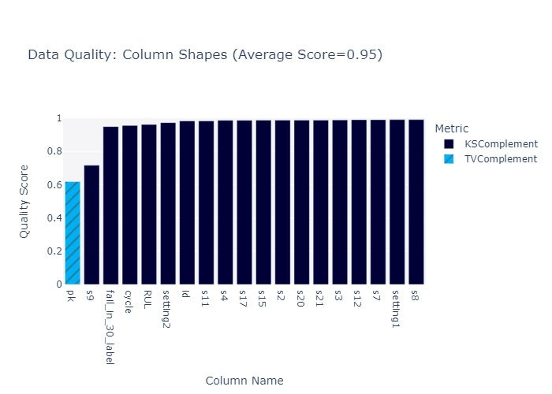

```python
fig= quality_report.get_visualization('Column Shapes')


# Render the plot as a static image
img_bytes = pio.to_image(fig, format='jpeg')

# Display the image
from IPython.display import Image
Image(img_bytes)
```

**Column Pairs**  
Measures the associations between columns, comparing real data vs synthetic

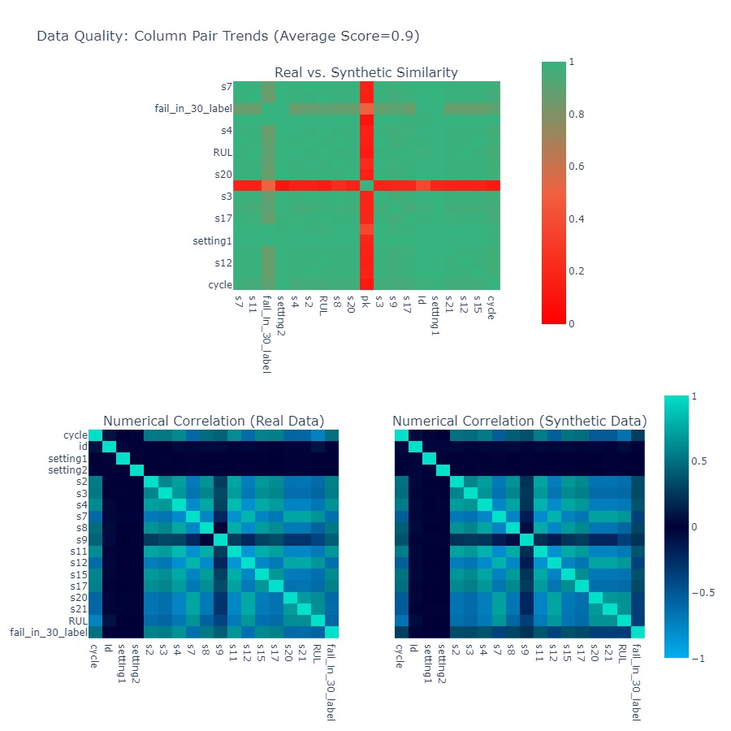

```python
fig=quality_report.get_visualization(property_name='Column Pair Trends')
# pyo.iplot(fig)

# Render the plot as a static image
img_bytes = pio.to_image(fig, format='jpeg')

# Display the image
from IPython.display import Image
Image(img_bytes)
```

**Diagnostics**  
Diagnostics check to see if the synthetic rows are pure copies of the real data,  
if the synthetic data covers the full range of values and  
if the synthetic data adheres to the original ranges.  
https://docs.sdv.dev/sdv/single-table-data/evaluation

```python
diagnostic_report = run_diagnostic(
    real_data=train_df_valid,
    synthetic_data=synthetic_data,
    metadata=metadata)
```

```
DiagnosticResults:

SUCCESS:
✓ The synthetic data covers over 90% of the numerical ranges present in the real data
✓ Over 90% of the synthetic rows are not copies of the real data
✓ The synthetic data follows over 90% of the min/max boundaries set by the real data

WARNING:
! The synthetic data is missing more than 10% of the categories present in the real data
```

**Visualize the best and worst comparison between synthetic and real data**

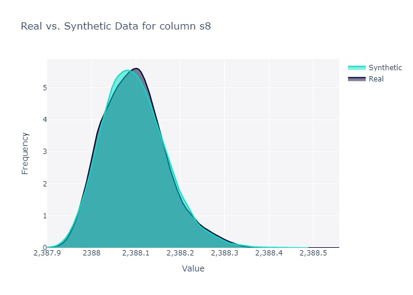

```python
# sensor 8 is best
fig = get_column_plot(
            real_data=train_df_valid,
            synthetic_data=synthetic_data,
            column_name='s8',
            metadata=metadata
)
# fig.show()
# Render the plot as a static image
img_bytes = pio.to_image(fig, format='jpeg')

# Display the image
Image(img_bytes)
```

Sensor 9 had the worst synthetic data compared to the real data. My interpretation is that the real data did not have a familiar distribution that could be used to generate new data. Indeed, when doing exploratory data analysis, this sensor had different patterns depending on the specific jet engine. Thus, it's not surprising that the synthetic data is not a good representation.

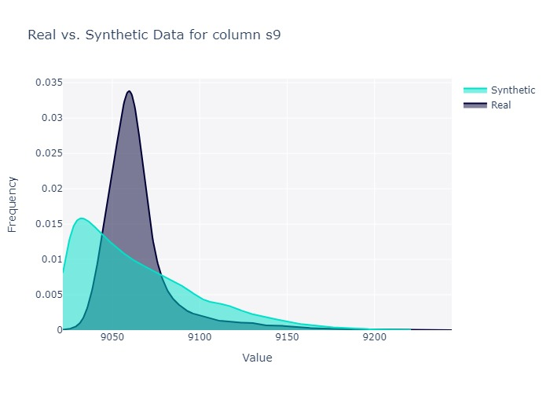

```python
# sensor 9 is worst
fig = get_column_plot(
            real_data=train_df_valid,
            synthetic_data=synthetic_data,
            column_name='s9',
            metadata=metadata
)
# fig.show()
# Render the plot as a static image
img_bytes = pio.to_image(fig, format='jpeg')

# Display the image
Image(img_bytes)
```

**Column Pairs Visualization**  
Note: From previous analysis, sensors 11, 4, 12 had the greatest predictive power on remaining-useful-life (RUL). Below are vizzes comparing real vs synthetic to RUL. While the overlap isn't perfect, it seems reasonably good.

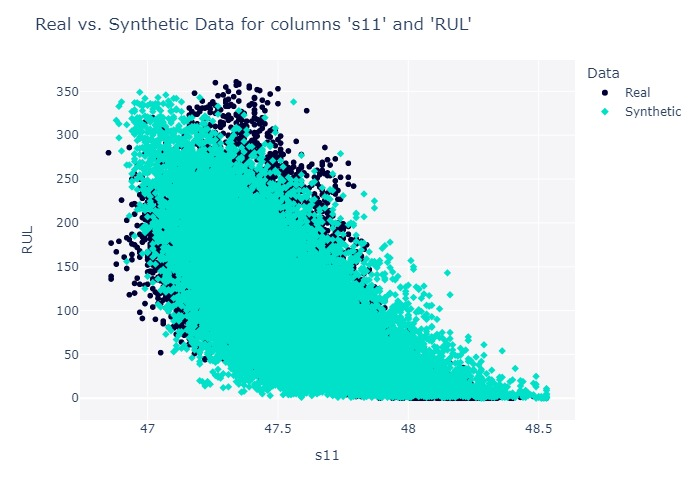

```python
fig = get_column_pair_plot(
    real_data=train_df_valid,
    synthetic_data=synthetic_data,
    column_names=['s11', 'RUL'],
    metadata=metadata)

# fig.show()

# Render the plot as a static image
img_bytes = pio.to_image(fig, format='jpeg')

# Display the image
Image(img_bytes)
```

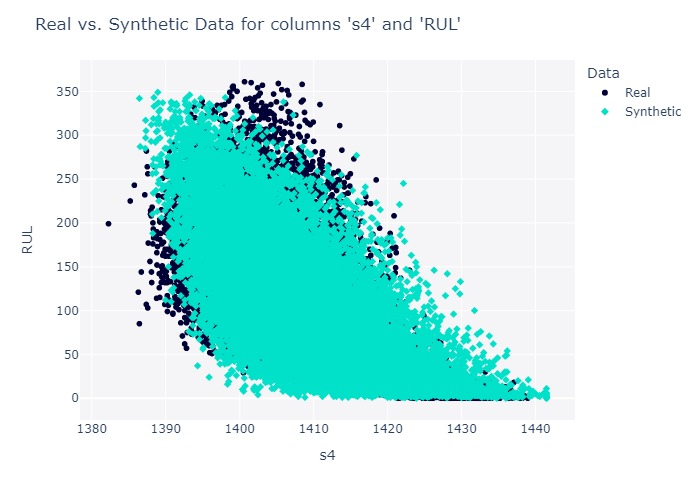

```python
fig = get_column_pair_plot(
    real_data=train_df_valid,
    synthetic_data=synthetic_data,
    column_names=['s4', 'RUL'],
    metadata=metadata)

# fig.show()
# Render the plot as a static image
img_bytes = pio.to_image(fig, format='jpeg')

# Display the image
Image(img_bytes)
```

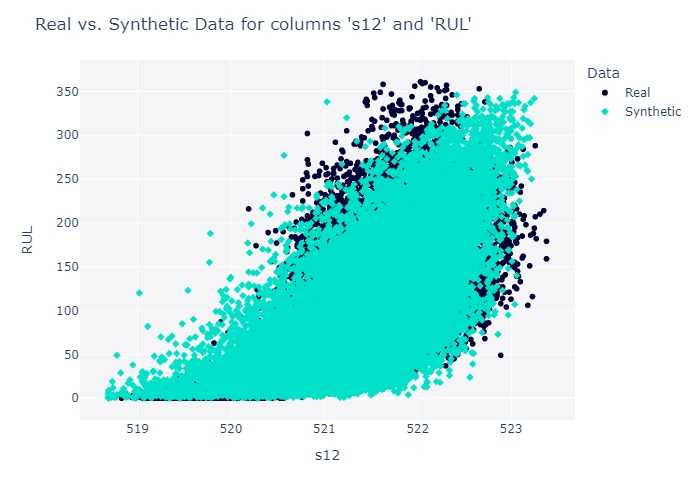

```python
fig = get_column_pair_plot(
    real_data=train_df_valid,
    synthetic_data=synthetic_data,
    column_names=['s12', 'RUL'],
    metadata=metadata)

# fig.show()
# Render the plot as a static image
img_bytes = pio.to_image(fig, format='jpeg')

# Display the image
Image(img_bytes)
```